# netcdf to map plotting

Kira Rehfeld

October 15, 2020

In this document I explore a couple of options for plotting spatial climate data using base R graphics. In particular using

- image
- image.plot from the fields package
- levelplot from the raster package
- and plotting spatialPointsDataFrames
- as well as spatialPolygonDataFrames, both from the raster package, which can be projected
- and using vector data from the naturalearthdata.com shapefiles

## Load libraries and set paths

## Prepare Natural Earth vector data

More shapes, resolutions and additional raster data can be obtained by download from naturalearthdata.com. This data is in the public domain, hence there needs to be no explicit citation/acknowledgement. !! On RC/DD this data is at /stacydata/resources/natural_earth_vector/

```r
# set up paths for physical and cultural vector data
shape_path <- "~/mydata/Rdata/natural_earth_vector/50m_physical/"
shape_path_cultural <- "~/mydata/Rdata/natural_earth_vector/50m_cultural/"

# file names
coast_shapefile <- paste(shape_path, "ne_50m_coastline.shp", sep="")
ocean_shapefile <- paste(shape_path, "ne_50m_ocean.shp", sep="")
admin0_shapefile <- paste(shape_path_cultural,"ne_50m_admin_0_countries.shp", sep="")
admin1_shapefile <- paste(shape_path_cultural, "ne_50m_admin_1_states_provinces_lakes.shp", sep="")
ogrListLayers(admin1_shapefile)
```

```
## [1] "ne_50m_admin_1_states_provinces_lakes"
## attr(,"driver")
## [1] "ESRI Shapefile"
## attr(,"nlayers")
## [1] 1
```

```r
# ogrListLayers gives an overview over the contents of the shapefile, but does not read it into memory

lakes_shapefile <- paste(shape_path, "ne_50m_lakes.shp", sep="")
bb_shapefile <- paste(shape_path, "ne_50m_graticules_all/ne_50m_wgs84_bounding_box.shp", sep="")
grat30_shapefile <- paste(shape_path, "ne_50m_graticules_all/ne_50m_graticules_30.shp", sep="")
ogrListLayers(grat30_shapefile)
```

```
## [1] "ne_50m_graticules_30"
## attr(,"driver")
## [1] "ESRI Shapefile"
## attr(,"nlayers")
## [1] 1
```

```r
# set some default values for colors, line widths, etc
names.shpz<-c("land","ocean","bb","lakes","grat30","countries","states")
col.shpz<-c("black","aliceblue","black","aliceblue","gray50","gray50","gray50")
lwd.shpz<-c(.1,.1,1,.1,.1,.1,.1)
shapnames<-c(coast_shapefile,ocean_shapefile,bb_shapefile,lakes_shapefile,grat30_shapefile,admin0_shapefile,admin1_shapefile)

shapz<-cbind(names.shpz,col.shpz,lwd.shpz,shapnames)

shpz<-as.list(shapnames); names(shpz)<-names.shpz

# read in the vector shapes into a list
shpz.vecs<-lapply(shapnames,readOGR)
# read in specifically the coastal shapefile
coast_lines<-readOGR(coast_shapefile)
summary(coast_lines)
```

```
## Object of class SpatialLinesDataFrame
## Coordinates:
##          min       max
## x -180.00000 180.00000
## y  -85.19219  83.59961
## Is projected: FALSE
## proj4string : [+proj=longlat +datum=WGS84 +no_defs]
## Data attributes:
##  scalerank     featurecla      min_zoom
##  0:1428    Coastline:1428   Min.   :0.000
##                             1st Qu.:2.000
##                             Median :3.000
##                             Mean   :2.716
##                             3rd Qu.:3.000
##                             Max.   :4.000
```

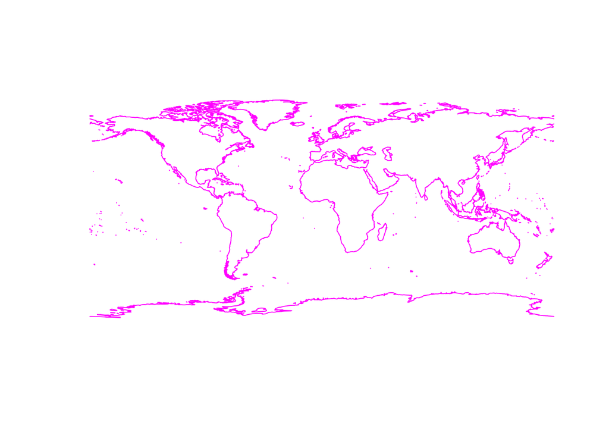

```r
plot(coast_lines,col="magenta")
```

```r
# obtain the original projection string (if reprojection is desired)
unproj_proj4string <- proj4string(coast_lines)

# if necessary, transform these components by spTransform
#coast_lines_proj <- spTransform(coast_lines, robin_crs)
```

## Get an overview over the vector objects from NaturalEarth and the default values

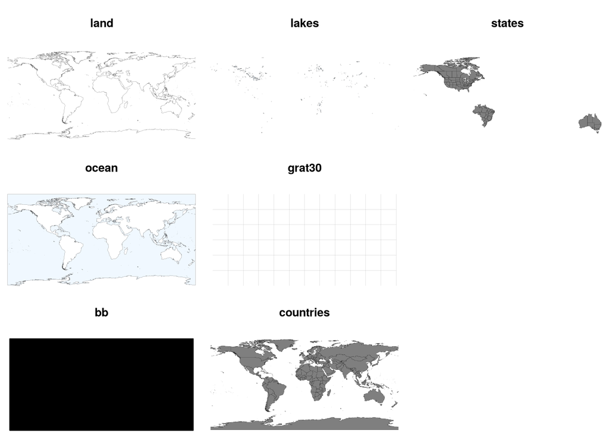

```r
layout(mat = matrix(seq(1,9),ncol=3,nrow=3))
par(mar=c(0,0,4,0))
plot(shpz.vecs[[1]],col=col.shpz[1],lwd=lwd.shpz[1],main=names(shpz)[1])
for (i in 2:length(shpz.vecs)){
  plot(shpz.vecs[[i]],col=col.shpz[i],lwd=lwd.shpz[i],main=names(shpz)[i])
}
```

## Prepare data objects

```r
ncf<-ncdf4::nc_open(fnam)
d<-list()
d$data<-ncdf4::ncvar_get(ncf,varid = "tas")
d$lon<-ncdf4::ncvar_get(ncf,varid="lon")
d$lat<-ncdf4::ncvar_get(ncf,varid="lat")

# for image plot, reverse latitude
d2<-d
d2$lat<-rev(d$lat)
d2$data<-d$data[,ncol(d$data):1]
```

## Simplest plots -- image and image plot!

Simply add points by lat/lon values since there is no projection.

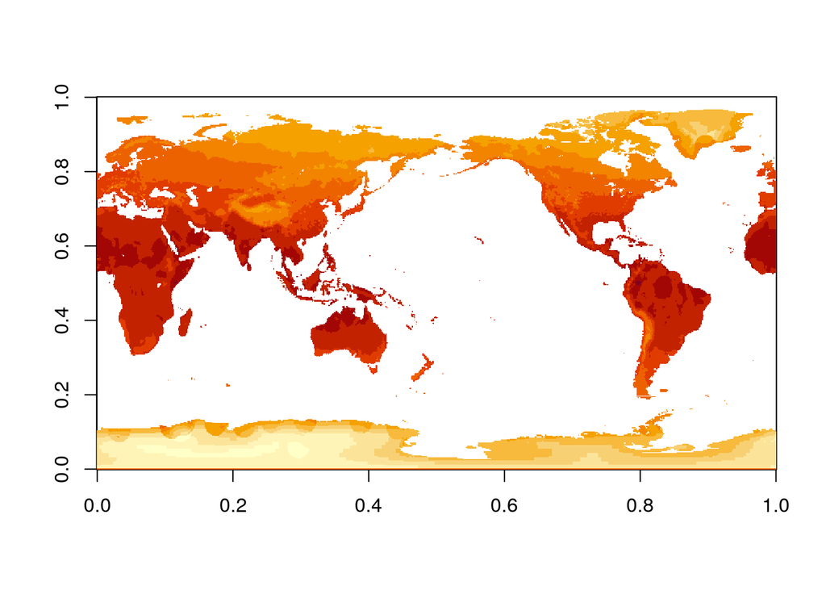

```r
image(d2$data)
```

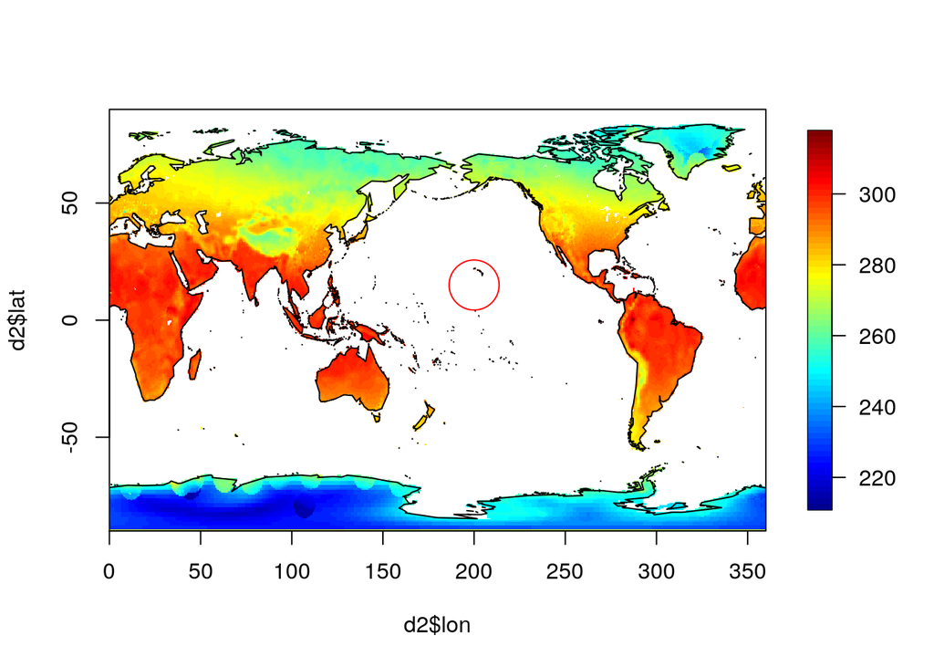

```r
fields::image.plot(d2$lon,d2$lat,d2$data)
maps::map("world2",add=TRUE,interior = FALSE)
points(200,15,col="red",pch=1,cex=5)
```

## Level plot from the raster package with marginal stats

The raster package can read netcdf files directly, and atttempts to find the lat/lon values and the projection. The function *extract* can be used to find values along lines, in polygons, etc. The function *getValues* returns the data values of the raster object

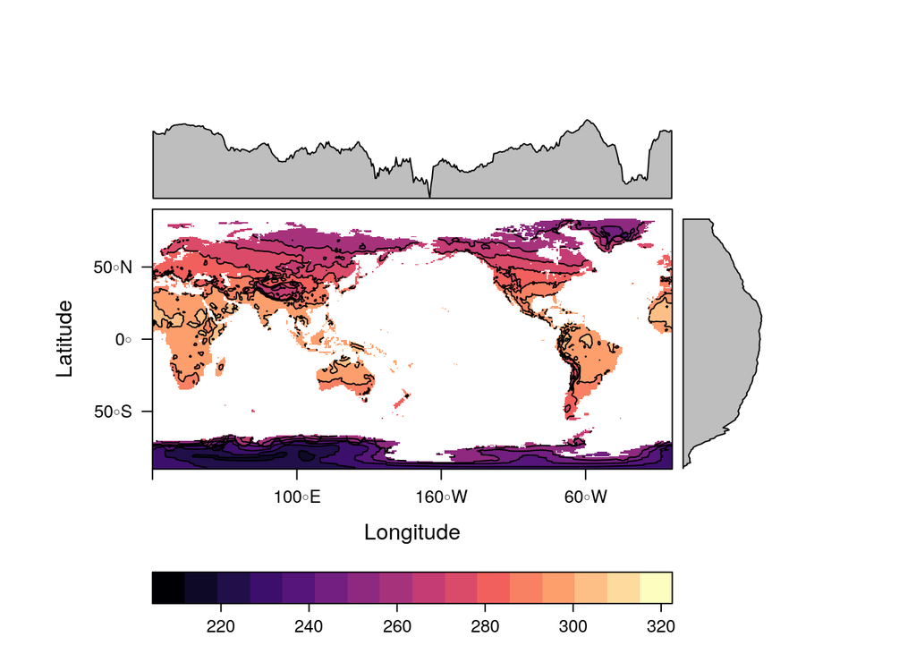

```r
tree<-raster(fnam)
projstr_orig<-projection(tree)

rasterVis::levelplot(tree,contour=TRUE, names.attr=c('R'))
```

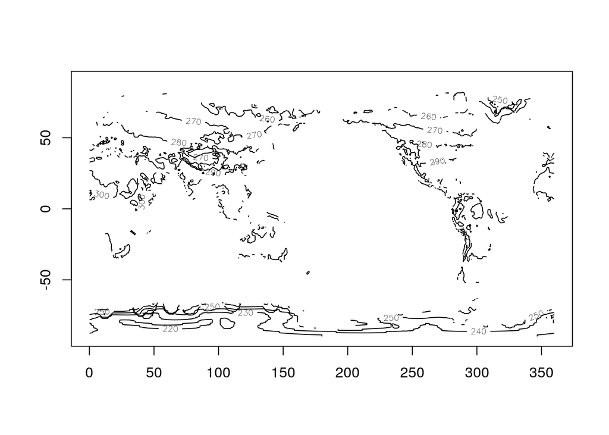

```r
raster::contour(tree)
```

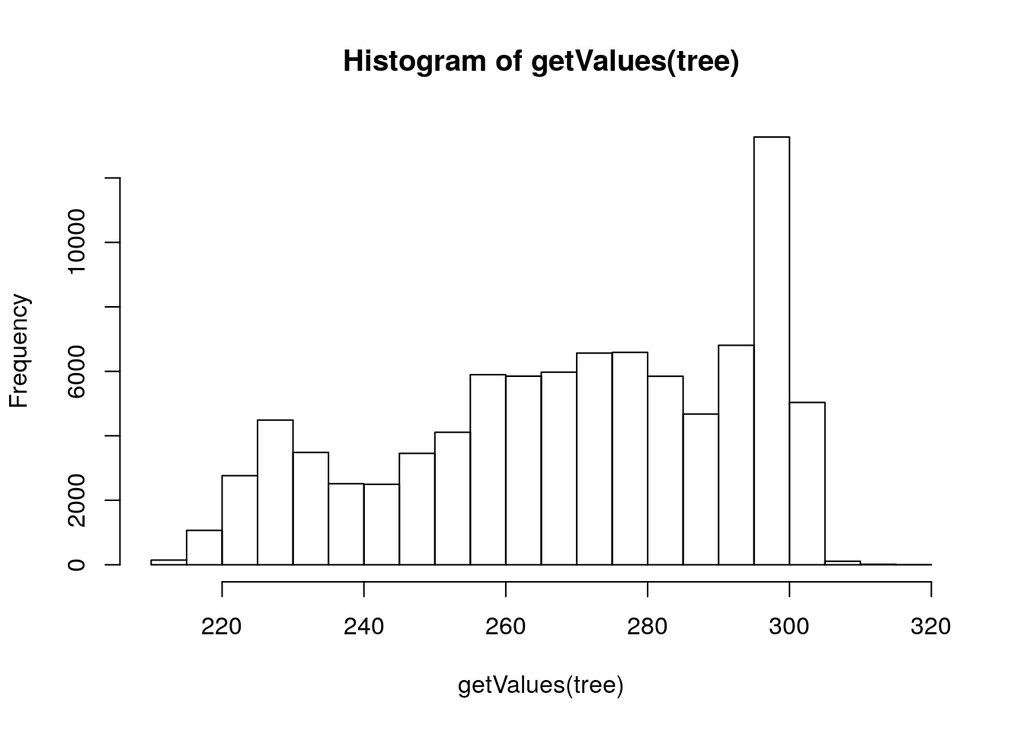

```r
hist(getValues(tree))
```

```r
#extract()
```

## Plot netcdf from raster as projected points (SpatialPointsDataFrame)

```r
tree_pts<-as(tree,"SpatialPointsDataFrame")
summary(tree_pts)
```

```
## Object of class SpatialPointsDataFrame
## Coordinates:
##      min    max
## x   0.25 359.75
## y -89.75  83.75
## Is projected: FALSE
## proj4string :
## [+proj=longlat +datum=WGS84 +ellps=WGS84 +towgs84=0,0,0]
## Number of points: 91157
## Data attributes:
##  Monthly.mean.of.surface.temperature
##  Min.   :211.7
##  1st Qu.:252.8
##  Median :272.9
##  Mean   :269.6
##  3rd Qu.:292.1
##  Max.   :317.1
```

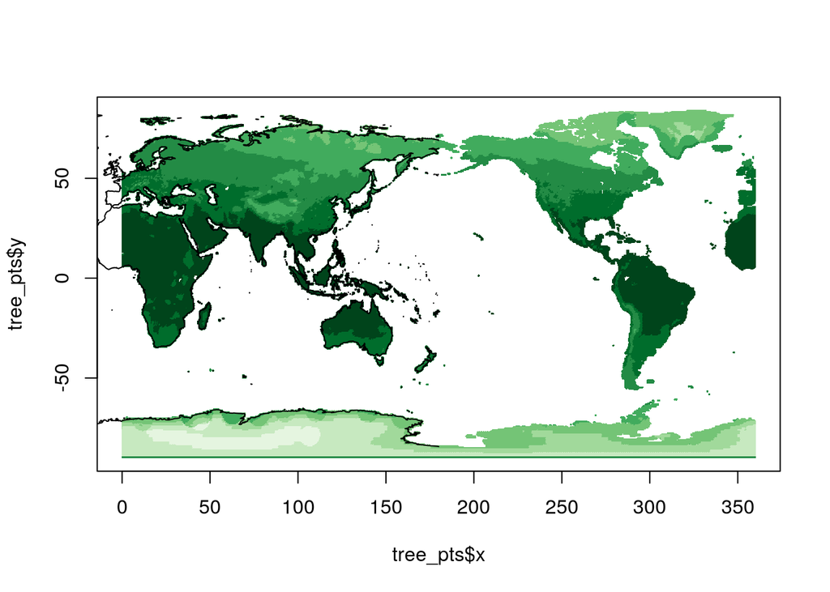

```r
plotclr <- brewer.pal(9,"Greens")
cutpts <- seq(min(d2$data,na.rm=TRUE),max(d2$data,na.rm=TRUE),length.out = 10)
color_class <- findInterval(tree_pts[["Monthly.mean.of.surface.temperature"]], cutpts)+1
plot(tree_pts$x, tree_pts$y, col=plotclr[color_class], pch=16, cex=0.25)
plot(coast_lines, add=TRUE,wrap=TRUE) # from naturalearth.com
```

```r
# need to check why parts are missing/wrap is incorrect
```

## Plot netcdf from raster as projected points (SpatialPointsDataFrame)

```r
tree_pts_proj <- spTransform(tree_pts, robin_crs)
coast_lines_proj <- spTransform(coast_lines, robin_crs)
bb_lines_proj <- spTransform(shpz.vecs[[3]], robin_crs)
summary(tree_pts_proj)
```

```
## Object of class SpatialPointsDataFrame
## Coordinates:
##         min      max
## x -16769395 16782196
## y  -8617891  8349164
## Is projected: TRUE
## proj4string : [+proj=robin +lon_0=0w +ellps=WGS84]
## Number of points: 91157
## Data attributes:
##  Monthly.mean.of.surface.temperature
##  Min.   :211.7
##  1st Qu.:252.8
##  Median :272.9
##  Mean   :269.6
##  3rd Qu.:292.1
##  Max.   :317.1
```

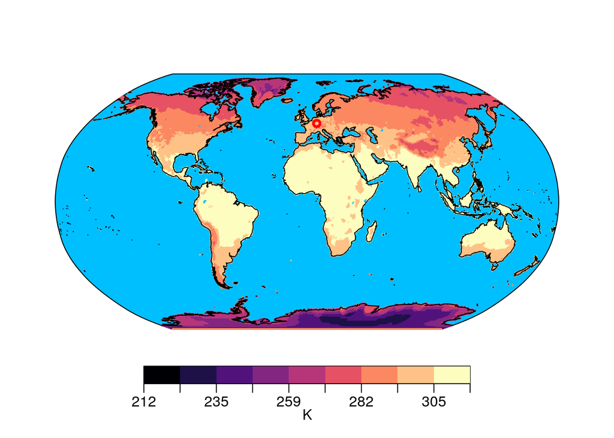

```r
#plotclr <- brewer.pal(9,"Greens")
plotclr<-viridisLite::magma(n = 9)
#cutpts <- c(10,20,30,40,50,60,70,80,90)
#color_class <- findInterval(tree_pts_proj$treecov, cutpts)+1
cutpts <- seq(min(getValues(tree),na.rm=TRUE),max(getValues(tree),na.rm=TRUE),length.out = 10)
color_class <- findInterval(tree_pts[["Monthly.mean.of.surface.temperature"]], cutpts)+1
par(mar=c(4,2,2,2))
plot(bb_lines_proj, col="deepskyblue", bor="black",axes=FALSE,xlab="",ylab="")
points(tree_pts_proj$x, tree_pts_proj$y, col=plotclr[color_class], pch=16, cex=0.25)
plot(coast_lines_proj, add=TRUE)
#  legend(-17000000, -5000000, legend=c("< 10","10 - 100","100 - 1000","> 1000"), bg="white",
 #   title="Number of Samples", pch=2, pt.lwd=0.6, col=plot, cex=0.5)

# Project and add a single point
crds <- matrix(data=c(8, 49.52), ncol=2)
spPointHD <- spTransform(SpatialPoints(coords=crds,
 proj4string=unproj_crs),robin_crs)
points(spPointHD,col="red",lwd=3)


# add legend strip
image.plot(getValues(tree),col = plotclr,breaks=cutpts,add = TRUE,legend.only = TRUE,horizontal = TRUE,legend.lab="K",legend.line=1.25,legend.width=1,legend.shrink=0.6,midpoint=TRUE,axis.args=list(at=cutpts,labels=round(cutpts),mgp=c(3,0.5,0))  )
```

```r
# reduced spacing by mgp, which can also be set globally with par(). check current values by par()$mgp
#par(mgp=c(axis.title.position, axis.label.position, axis.line.position))]
```

## Set up polygon plot for netcdf file (SpatialPolygonsDataFrame)

```r
tree<-raster(fnam)
projstr_orig<-projection(tree)
tree_poly <- as(tree, "SpatialPolygonsDataFrame")
summary(tree_poly)
```

```
## Object of class SpatialPolygonsDataFrame
## Coordinates:
##   min max
## x   0 360
## y -90  84
## Is projected: FALSE
## proj4string :
## [+proj=longlat +datum=WGS84 +ellps=WGS84 +towgs84=0,0,0]
## Data attributes:
##  Monthly.mean.of.surface.temperature
##  Min.   :211.7
##  1st Qu.:252.8
##  Median :272.9
##  Mean   :269.6
##  3rd Qu.:292.1
##  Max.   :317.1
```

```r
tree_poly_proj <- spTransform(tree_poly, robin_crs)
```

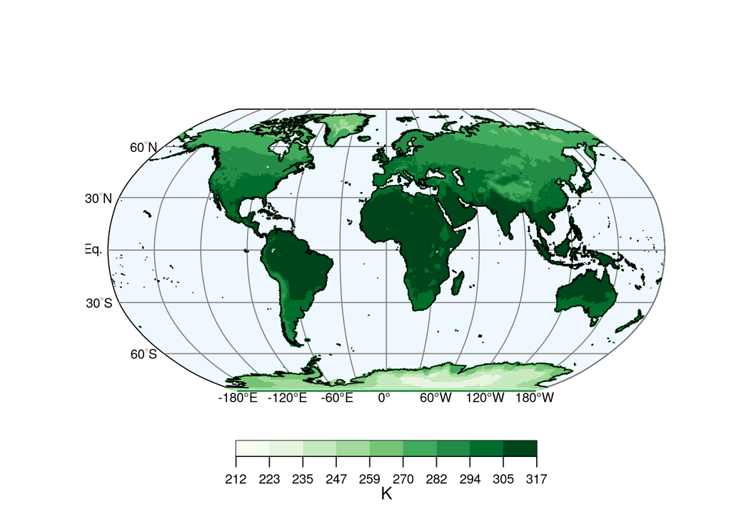

```r
# set up plot colors
plotclr <- brewer.pal(9,"Greens")
#cutpts <- c(10,20,30,40,50,60,70,80,90)
#color_class <- findInterval(tree_pts_proj$treecov, cutpts)+1
cutpts <- seq(min(getValues(tree),na.rm=TRUE),max(getValues(tree),na.rm=TRUE),length.out = 10)
color_class <- findInterval(tree_pts[["Monthly.mean.of.surface.temperature"]], cutpts)+1
clr<-plotclr[color_class] # color vector for polygons

# set up axis labels for latitude
data.ax=as.matrix(cbind(rep(-180,5),seq(-60,60,by=30)),ncol=2)
SP.in<-SpatialPoints(coords = data.ax,proj4string = unproj_crs)
SP<-spTransform(SP.in,robin_crs)
SPlab<-c(expression("60"^degree*S),expression("30"^degree*S),"Eq.",expression("30"^degree*N),expression("60"^degree*N))

# longitude
data.axx=as.matrix(cbind(seq(-180,180,by=60),rep(-90,7)),ncol=2)
SP.in.x<-SpatialPoints(coords = data.axx,proj4string = unproj_crs)
SP.x<-spTransform(SP.in.x,robin_crs)
#SPlab<-c(expression("60"^degree*S),expression("30"^degree*S),"Eq.",expression("30"^degree*N),expression("60"^degree*N))
#SPlab.x<-paste0(rep("expression(",7),seq(-180,180,by=60),rep("^degree*",7),c("E","E","E"," ","W","W","W"),rep(")",7))
#SPlab.x<-paste0(seq(-180,180,by=60),rep("^degree*",7),c("E","E","E"," ","W","W","W"))
SPlab.x<-paste0(seq(-180,180,by=60),rep("°",7),c("E","E","E"," ","W","W","W"))
# project naturalearth shapefiles
shpz.proj<-lapply(shpz.vecs,spTransform,robin_crs)

# begin plot
plot(shpz.proj[[3]],col="aliceblue",bor="black")#bb
plot(shpz.proj[[5]],col=col.shpz[5],bor=col.shpz[5],add=TRUE)#graticules
#plot(tree_poly_proj,col=clr,bor=clr,ljoin="bevel",add=TRUE)
points(tree_pts_proj$x, tree_pts_proj$y, col=plotclr[color_class], pch=16, cex=0.25) # points are much faster to plot!
plot(shpz.proj[[1]],col="black",bor="black",add=TRUE)#land
#plot(coast_lines_proj, col="black",add=TRUE)


text(coordinates(SP),labels=SPlab,adj=c(1.25,0.5),cex = 0.75)
text(coordinates(SP.x),labels=eval(SPlab.x),adj=c(0.5,1.15),cex = 0.75)

# add legend strip
image.plot(getValues(tree),col = plotclr,breaks=cutpts,add = TRUE,legend.only = TRUE,horizontal = TRUE,legend.lab="K",legend.line=1.25,legend.width=0.75,legend.shrink=0.5,midpoint=TRUE,axis.args=list(cex.axis=0.75,at=cutpts,labels=round(cutpts),mgp=c(3,0.5,0))  )
```